# Case Study

Muhammad Hilmi Abdul Majid

## Introduction

We have covered several topics related to data visualization and analysis from the principle of data visualization to producing good visuals. Now it is time to put it into practice. In this topic, we will present a case study and show the steps taken to analyse the given data.

As usual, we will first load the important packages.

```r
library(ggplot2)
library(dplyr)
```

## Stroke Risk Factors

In this case study, we would like to use a data from kaggle on the topic of stroke and the factors associating to it. The data is originally from the Electronic Health Record (EHR) controlled by McKinsey & Company, and were used in a hackathon. Unfortunately, the original data with 43400 patients is no longer available. The current data shared in kaggle is only a subset of the original data.

## Data Gathering and Objectives

In any data analysis, the source of data should be questioned first. Is it reliable? Can it be trusted? The importance of good and high quality data source must not be underestimated. If the data is unreliable, all the subsequent analysis becomes questionable. However, in our case study here, since the source is confidential, we would not be able to verify it and will only use it for educational purposes.

You can download the data from kaggle (https://www.kaggle.com/datasets/fedesoriano/stroke-prediction-dataset) and read through the details.

After obtaining the data, we can then begin to ask, what is it that we want to achieve from our visualization? What is the objectives of this activity? The answer depends on the context, and what the reader/viewer expect to see from the data visualization. In our case study here, what we want to investigate is the various factors that may affect the chance of getting stroke.

In the data exploration part, we may want to ask these question:

- How many patients are included in the data? How many of them have stroke, and how many of them do not have stroke?
- What are the available columns in the data set?
- What are the available possible risk factors in the data set?

Then, we would like to ask some more specific questions such as:

- Which possible risk factors lead to higher chance of getting stroke?
- How does the age distribution differs between those who have stroke and those that do not have stroke?
- Similarly, how do the glucose level and BMI distribution differ between those who have stroke and those that do not have stroke?

## Data Exploration

After downloading the data, we can load it into R. Since the data is in CSV format, we can use `read.csv()` function to load it. Then, we can use `head()` function to print out the first few rows.

```r
stroke_data <- read.csv("dataset\\healthcare-dataset-stroke-data.csv")
head(stroke_data)
```

```
##      id gender age hypertension heart_disease ever_married     work_type
## 1  9046   Male  67            0             1          Yes       Private
## 2 51676 Female  61            0             0          Yes Self-employed
## 3 31112   Male  80            0             1          Yes       Private
## 4 60182 Female  49            0             0          Yes       Private
## 5  1665 Female  79            1             0          Yes Self-employed
## 6 56669   Male  81            0             0          Yes       Private
##   Residence_type avg_glucose_level  bmi  smoking_status stroke
## 1          Urban            228.69 36.6 formerly smoked      1
## 2          Rural            202.21  N/A    never smoked      1
## 3          Rural            105.92 32.5    never smoked      1
## 4          Urban            171.23 34.4          smokes      1
## 5          Rural            174.12   24    never smoked      1
## 6          Urban            186.21   29 formerly smoked      1
```

To print out all the columns in the data, we can use the `names()` function.

```r
names(stroke_data)
```

```
##  [1] "id"                "gender"            "age"
##  [4] "hypertension"      "heart_disease"     "ever_married"
##  [7] "work_type"         "Residence_type"    "avg_glucose_level"
## [10] "bmi"               "smoking_status"    "stroke"
```

We can also use `str()` function to see the structure of the data set.

```r
str(stroke_data)
```

```
## 'data.frame':    5110 obs. of  12 variables:
##  $ id               : int  9046 51676 31112 60182 1665 56669 53882 10434 27419 60491 ...
##  $ gender           : chr  "Male" "Female" "Male" "Female" ...
##  $ age              : num  67 61 80 49 79 81 74 69 59 78 ...
##  $ hypertension     : int  0 0 0 0 1 0 1 0 0 0 ...
##  $ heart_disease    : int  1 0 1 0 0 0 1 0 0 0 ...
##  $ ever_married     : chr  "Yes" "Yes" "Yes" "Yes" ...
##  $ work_type        : chr  "Private" "Self-employed" "Private" "Private" ...
##  $ Residence_type   : chr  "Urban" "Rural" "Rural" "Urban" ...
##  $ avg_glucose_level: num  229 202 106 171 174 ...
##  $ bmi              : chr  "36.6" "N/A" "32.5" "34.4" ...
##  $ smoking_status   : chr  "formerly smoked" "never smoked" "never smoked" "smokes" ...
##  $ stroke           : int  1 1 1 1 1 1 1 1 1 1 ...
```

We can see that we have `id`, `gender`, `age`, `hypertension`, `heart_disease`, `ever_married`, `work_type`, `Residence_type`, `avg_glucose_level`, `bmi`, `smoking_status`, and lastly `stroke` in the data set. Based on the names (and the description of data from kaggle), the possible risk factors are gender (male/female), age, hypertension (yes/no), heart disease (yes/no), ever married (yes/no), work type, residence type (rural/urban), average glucose level, BMI, and smoking status.

Notice also that for the `bmi` column, the type of data is shown as `chr` or character instead of number. This is because the column contains `"N/A"` values.

Another useful function is the `summary()`, which can give a brief summary of the data.

```r
summary(stroke_data)
```

```
##        id           gender               age         hypertension
##  Min.   :   67   Length:5110        Min.   : 0.08   Min.   :0.00000
##  1st Qu.:17741   Class :character   1st Qu.:25.00   1st Qu.:0.00000
##  Median :36932   Mode  :character   Median :45.00   Median :0.00000
##  Mean   :36518                      Mean   :43.23   Mean   :0.09746
##  3rd Qu.:54682                      3rd Qu.:61.00   3rd Qu.:0.00000
##  Max.   :72940                      Max.   :82.00   Max.   :1.00000
##  heart_disease     ever_married        work_type         Residence_type
##  Min.   :0.00000   Length:5110        Length:5110        Length:5110
##  1st Qu.:0.00000   Class :character   Class :character   Class :character
##  Median :0.00000   Mode  :character   Mode  :character   Mode  :character
##  Mean   :0.05401
##  3rd Qu.:0.00000
##  Max.   :1.00000
##  avg_glucose_level     bmi            smoking_status         stroke
##  Min.   : 55.12    Length:5110        Length:5110        Min.   :0.00000
##  1st Qu.: 77.25    Class :character   Class :character   1st Qu.:0.00000
##  Median : 91.89    Mode  :character   Mode  :character   Median :0.00000
##  Mean   :106.15                                          Mean   :0.04873
##  3rd Qu.:114.09                                          3rd Qu.:0.00000
##  Max.   :271.74                                          Max.   :1.00000
```

Pay attention at the `age` column, which has the minimum value of 0.08. For further analysis, we may want to put a limit on the age.

To check the number of rows in the data set, we can use the `nrow()` function.

```r
nrow(stroke_data)
```

```
## [1] 5110
```

So there are 5110 patients in the data set. To check the number of patients with and without stroke, we can use the `table()` function to find the frequencies.

```r
table(stroke_data$stroke)
```

```
##
##    0    1
## 4861  249
```

Out of 5110 patients, 4861 of them do not have stroke and 249 of them have stroke.

The `table()` function can also show us the two way table to see the distribution of data. For example, if we want to see the data distribution of gender by stroke, we use the following code.

```r
table(stroke_data$gender, stroke_data$stroke)
```

```
##
##             0    1
##   Female 2853  141
##   Male   2007  108
##   Other     1    0
```

We can do this for all the available columns if we wish for, but showing them here is tedious.

To see all the available values in a column, we can use the `unique()` function.

```r
unique(stroke_data$smoking_status)
```

```
## [1] "formerly smoked" "never smoked"    "smokes"          "Unknown"
```

```r
stroke_data2 <- stroke_data %>%
  mutate(hypertension = ifelse(hypertension == 0, "No", "Yes"),
         heart_disease = ifelse(heart_disease == 0, "No", "Yes"),
         stroke = ifelse(stroke == 0, "No", "Yes"),
         smoke = ifelse(smoking_status %in% c("formerly smoked","smokes"),"Yes","No"),
         bmi = as.numeric(bmi)) %>%
  select(-"smoking_status") %>%
  filter(age >= 10)

str(stroke_data2)
```

```
## 'data.frame':    4638 obs. of  12 variables:
##  $ id               : int  9046 51676 31112 60182 1665 56669 53882 10434 27419 60491 ...
##  $ gender           : chr  "Male" "Female" "Male" "Female" ...
##  $ age              : num  67 61 80 49 79 81 74 69 59 78 ...
##  $ hypertension     : chr  "No" "No" "No" "No" ...
##  $ heart_disease    : chr  "Yes" "No" "Yes" "No" ...
##  $ ever_married     : chr  "Yes" "Yes" "Yes" "Yes" ...
##  $ work_type        : chr  "Private" "Self-employed" "Private" "Private" ...
##  $ Residence_type   : chr  "Urban" "Rural" "Rural" "Urban" ...
##  $ avg_glucose_level: num  229 202 106 171 174 ...
##  $ bmi              : num  36.6 NA 32.5 34.4 24 29 27.4 22.8 NA 24.2 ...
##  $ stroke           : chr  "Yes" "Yes" "Yes" "Yes" ...
##  $ smoke            : chr  "Yes" "No" "No" "Yes" ...
```

```r
table(stroke_data2$stroke)
```

```
##
##   No  Yes
## 4390  248
```

Thus, we are left with 4638 observations with 4390 (94.65%) of them not having stroke, while 248 (5.35%) of them having stroke.

## Early Data Visualization

After understanding the objectives and the data more by exploring it, we can start with the process of building visuals to display the data. Note that the visuals produced in this section are not finalized. Thus, we do not care much about the colors or themes and can make changes at the end. We are still exploring the data, but visually unlike before, and try to decide what story we can tell to the audience.

### Patients demographic

First, let’s look at the patients demographic. To do so, we can use the bar charts for each of the categorical variables, and scatterplots for the quantitative variables.

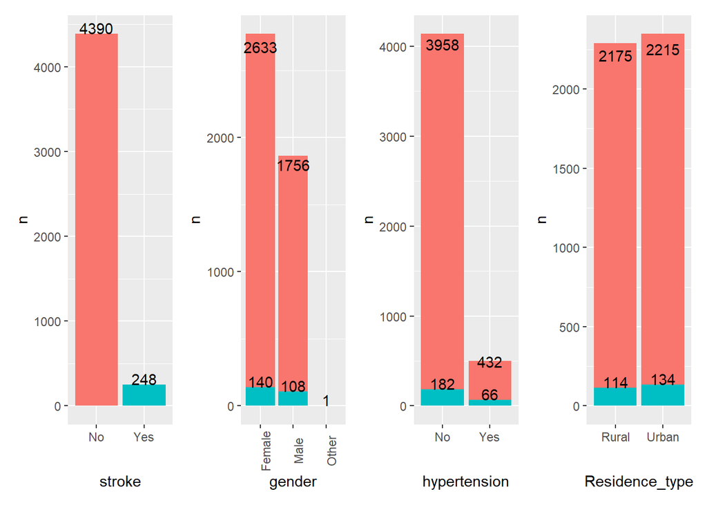

```r
library(patchwork)

df <- count(stroke_data2, stroke)
p1 <- ggplot(df, aes(x=stroke, y=n, label=n, fill=stroke)) +
  geom_col() +
  geom_text(vjust=0) +
  theme(legend.position = "none")

df <- count(stroke_data2, gender, stroke)
p2 <- ggplot(df, aes(x=gender, y=n, fill=stroke, label=n)) +
  geom_col() +
  geom_text(vjust=0) +
  theme(legend.position = "none",
        axis.text.x = element_text(angle = 90))

df <- count(stroke_data2, hypertension, stroke)
p3 <- ggplot(df, aes(x=hypertension, y=n, fill=stroke, label=n)) +
  geom_col() +
  geom_text(vjust=0) +
  theme(legend.position = "none")

df <- count(stroke_data2, Residence_type, stroke)
p4 <- ggplot(df, aes(x=Residence_type, y=n, fill=stroke, label=n)) +
  geom_col() +
  geom_text(vjust=0) +
  theme(legend.position = "none")

p1|p2|p3|p4
```

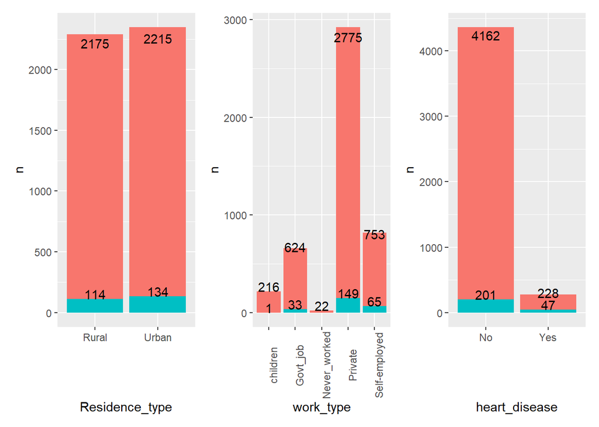

```r
df <- count(stroke_data2, work_type, stroke)
p5 <- ggplot(df, aes(x=work_type, y=n, fill=stroke, label=n)) +
  geom_col() +
  geom_text(vjust=0) +
  theme(legend.position = "none",
        axis.text.x = element_text(angle = 90))

df <- count(stroke_data2, heart_disease, stroke)
p6 <- ggplot(df, aes(x=heart_disease, y=n, fill=stroke, label=n)) +
  geom_col() +
  geom_text(vjust=0) +
  theme(legend.position = "none")

df <- count(stroke_data2, smoke, stroke)
p7 <- ggplot(df, aes(x=smoke, y=n, fill=stroke, label=n)) +
  geom_col() +
  geom_text(vjust=0)

p4|p5|p6
```

### Quantitative factors

Let’s look at the distribution of quantitative variables for patients with stroke and without stroke. One good way to do this is to use the kernel density plot.

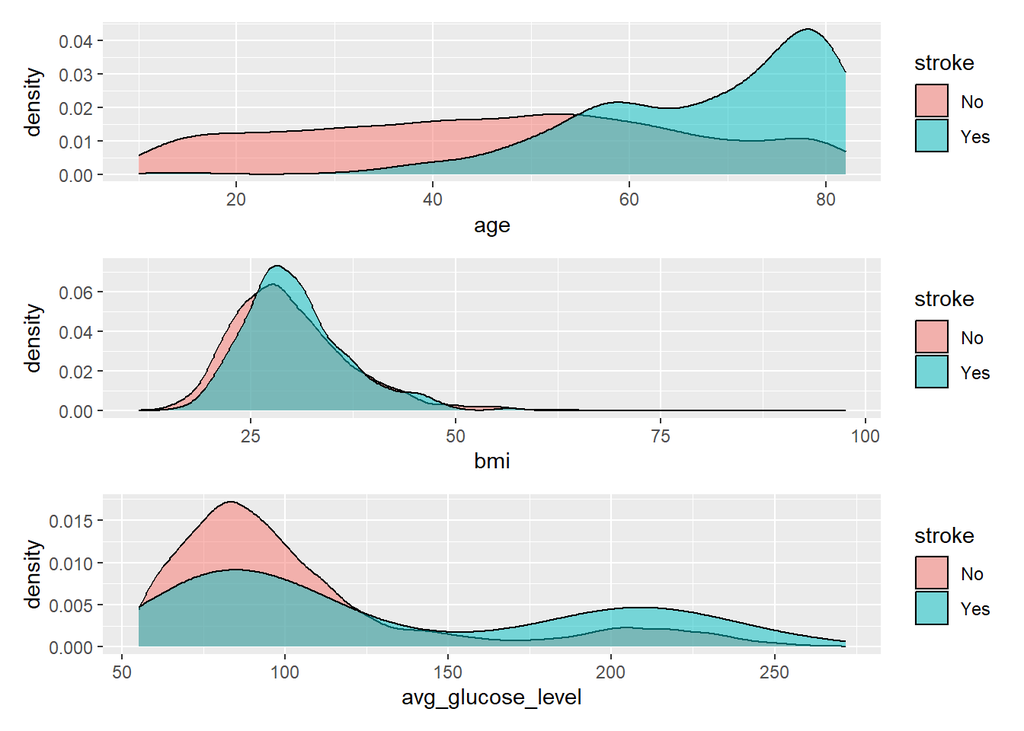

```r
library(patchwork)

p1 <- ggplot(stroke_data2, aes(x=age, fill=stroke)) +
  geom_density(alpha=0.5)

p2 <- ggplot(stroke_data2, aes(x=bmi, fill=stroke)) +
  geom_density(alpha=0.5)

p3 <- ggplot(stroke_data2, aes(x=avg_glucose_level, fill=stroke)) +
  geom_density(alpha=0.5)

p1/p2/p3
```

We can also try other plots such as boxplot or violin plots but personally, it seems kernel density plot is able to distinguish the two groups better in this data set.

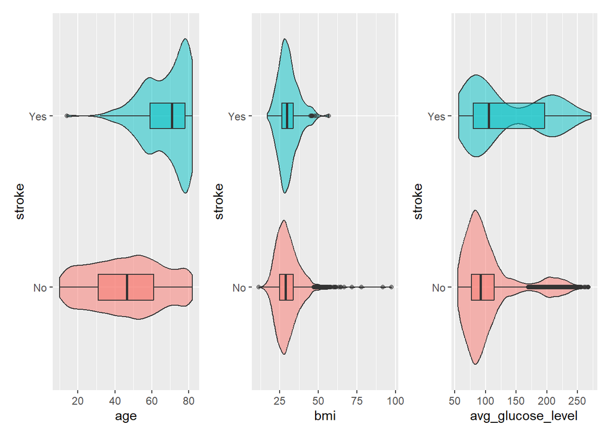

```r
library(patchwork)

p1 <- ggplot(stroke_data2, aes(x=age, y=stroke, fill=stroke)) +
  geom_violin(alpha=0.5) +
  geom_boxplot(width = 0.15, alpha=0.5) +
  theme(legend.position = "none")

p2 <- ggplot(stroke_data2, aes(x=bmi, y=stroke, fill=stroke)) +
  geom_violin(alpha=0.5) +
  geom_boxplot(width =0.15, alpha=0.5) +
  theme(legend.position = "none")

p3 <- ggplot(stroke_data2, aes(x=avg_glucose_level, y=stroke, fill=stroke)) +
  geom_violin(alpha=0.5) +
  geom_boxplot(width =0.15, alpha=0.5) +
  theme(legend.position = "none")

p1|p2|p3
```

We can see that in terms of age, those with stroke tends to be in the older range, whereas those without stroke are in all ranges of age. The BMI of those with and without stroke seems similar. And as for the average glucose level, both groups exhibit bimodal distribution but there tend to be more people in the higher range for patients with stroke compared to patients without stroke. From these observations, we can suggest that age and possibly glucose level are risk factors for stroke, where as BMI does not seem affect much.

### Categorical factors

Next, let’s look at the categorical factors. We can use bar charts to visualize the distribution of data for each group. But since only 5.35% of the data are for stroke patients, we might want to standardize the total to 100% by using the segmented or 100% bar chart. In the code below, a label is included to show the frequency of each subgroup because some subgroups only have small number of observations.

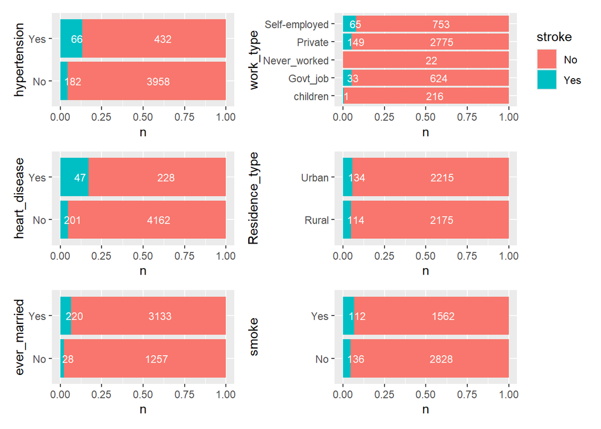

```r
df1 <- count(stroke_data2, hypertension, stroke)
p1 <- ggplot(df1, aes(y=hypertension, x=n, fill=stroke, label=n))+
  geom_col(position = "fill") +
  geom_text(position=position_fill(vjust=0.5),
             hjust=0, col="white", size=3, show.legend = FALSE) +
  theme(legend.position = "none")

df2 <- count(stroke_data2, heart_disease, stroke)
p2 <- ggplot(df2, aes(y=heart_disease, x=n, fill=stroke, label=n))+
  geom_col(position = "fill") +
  geom_text(position=position_fill(vjust=0.5),
             hjust=0, col="white", size=3, show.legend = FALSE) +
  theme(legend.position = "none")

df3 <- count(stroke_data2, ever_married, stroke)
p3 <- ggplot(df3, aes(y=ever_married, x=n, fill=stroke, label=n))+
  geom_col(position = "fill") +
  geom_text(position=position_fill(vjust=0.5),
             hjust=0, col="white", size=3, show.legend = FALSE) +
  theme(legend.position = "none")

df4 <- count(stroke_data2, work_type, stroke)
p4 <- ggplot(df4, aes(y=work_type, x=n, fill=stroke, label=n))+
  geom_col(position = "fill") +
  geom_text(position=position_fill(vjust=0.5),
             hjust=0, col="white", size=3, show.legend = FALSE)

df5 <- count(stroke_data2, Residence_type, stroke)
p5 <- ggplot(df5, aes(y=Residence_type, x=n, fill=stroke, label=n))+
  geom_col(position = "fill") +
  geom_text(position=position_fill(vjust=0.5),
             hjust=0, col="white", size=3, show.legend = FALSE) +
  theme(legend.position = "none")

df6 <- count(stroke_data2, smoke, stroke)
p6 <- ggplot(df6, aes(y=smoke, x=n, fill=stroke, label=n))+
  geom_col(position = "fill") +
  geom_text(position=position_fill(vjust=0.5),
             hjust=0, col="white", size=3, show.legend = FALSE) +
  theme(legend.position = "none")

(p1/p2/p3)|(p4/p5/p6)
```

Let’s analyze the produced visual. According to the segmented bar charts, the variables that have biggest difference in the not having or having stroke percentage are hypertension, heart disease, ever married, and possibly smoke. There is not much difference in the distribution of data for work and residential types, suggesting that these two variables may not be important to predict the stroke status of a patient.

### Association between variables

Next, let’s look at the association between the variables to see if there is any pattern or trend worth discussing. First, let’s look at the quantitative variables.

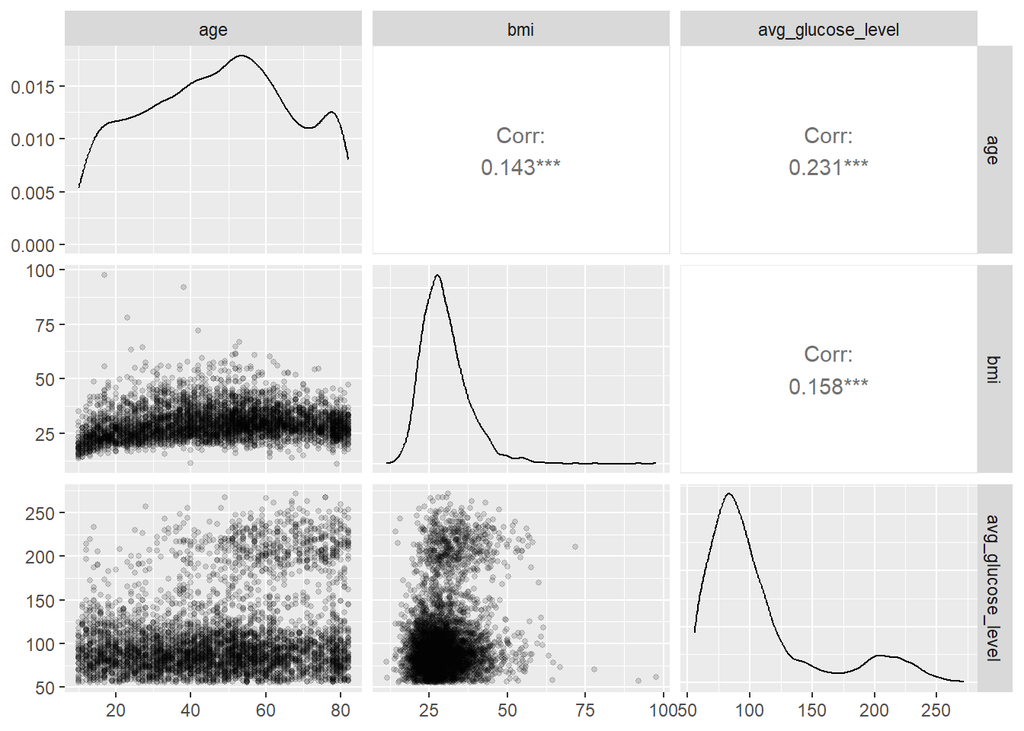

```r
library(GGally)

ggpairs(stroke_data2,
        columns=c("age", "bmi", "avg_glucose_level"),
        lower = list(continuous = wrap("points", alpha=0.15, size=1)),
        diag = list(continuous = wrap("densityDiag", alpha=0.5)))
```

The correlation coefficient are all positives and statistically significant. There might be some pattern for the age versus bmi scatterplot but they are not worth discussing. Similarly for age versus average glucose level. As for the BMI versus average glucose level, we can see the data are concentrated at two points. One with lower BMI and average glucose level, and another at a higher BMI and average glucose level.

We can focus our attention to the two variables by just producing scatterplot using them and as well as stroke indicator. Note that in the code below, the `arrange()` function is used so that points for patients without stroke are placed first in the canvas, followed by patients with stroke. This is due to the overwhelming number of patients without stroke that makes it difficult if the points are overlapping.

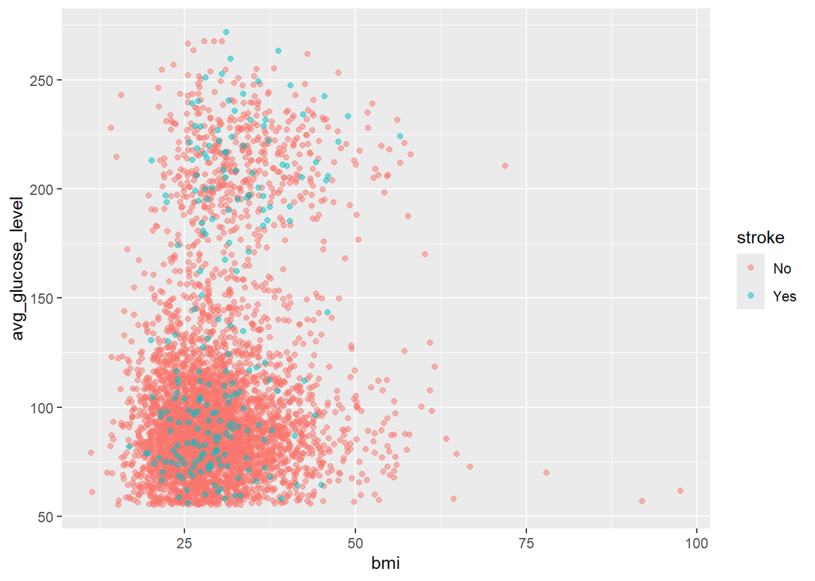

```r
ggplot(arrange(stroke_data2, stroke),
       aes(x=bmi, y=avg_glucose_level, color=stroke)) +
  geom_point(alpha=0.5)
```

From the scatterplot, we see that the BMI versus average glucose level are concentrated at two regions. However, patients without stroke are more concentrated in the bottom left region, whereas patients with stroke are not as concentrated as patients without stroke.

In the previous analysis for categorical data, we mentioned that ever married might be an important factor for stroke as those that have married tend to have higher percentage of stroke occurrences. However, does that make sense? Does getting married cause stroke? While it is true that those who have married have a higher tendency of getting stroke, the reason for it is possibly due to age, as those who are younger tend to be not married compared to older people.

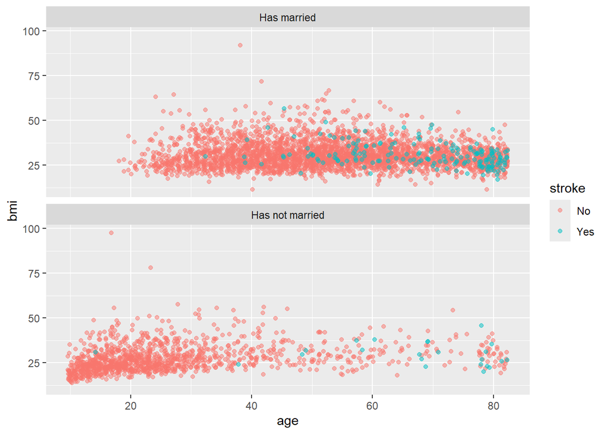

```r
df <- mutate(stroke_data2,
             ever_married = ifelse(ever_married == "Yes", "Has married",
                                   "Has not married"))

ggplot(arrange(df, stroke), aes(x=age, y=bmi, color=stroke)) +
  geom_point(alpha=0.5, position = position_jitter()) +
  facet_wrap(~ever_married, ncol = 1, labeller = )
```

In the chart above, we can see that yes, there are more people having stroke and married compared to those who have not married. But we can also see age-wise, those who have married tend to be older.

## Findings and Finalizing Visuals

Now that we have explored the data and produced some visuals, we can proceed to finalizing the visuals to be shared to the audience. Our visuals must satisfy the objectives of the investigation. In our case study here, we want to identify which factors are associated with stroke, based on the data set.

Here are some findings we have found from the analysis:

- Age is one of the main factor of stroke. Stroke tends to occur to those in the older age-range compared to the younger patients.
- BMI may not be a factor of stroke, at least according to the data set. The distribution of BMI between the two groups are similar.
- Average glucose level is possibly another factor of stroke with higher average glucose level associated with stroke occurrence.
- Ever married is another factor associated with stroke. But this factor should be ignored as the association is due to its connection to age.
- Hypertension, heart disease, and has smoked are other factors that are associated with stroke.
- Work and residential types may not be associated with stroke.

From the findings, we can now proceed to finalizing visuals that share the same conclusions. At this stage, we need to think about what to include and what not to include when producing the visuals. For example, we may want to focus only on factors that are associated with stroke, and ignore BMI, ever married, and work and residential type variables from further analysis.

For the age and average glucose level, we can use the kernel density plot.

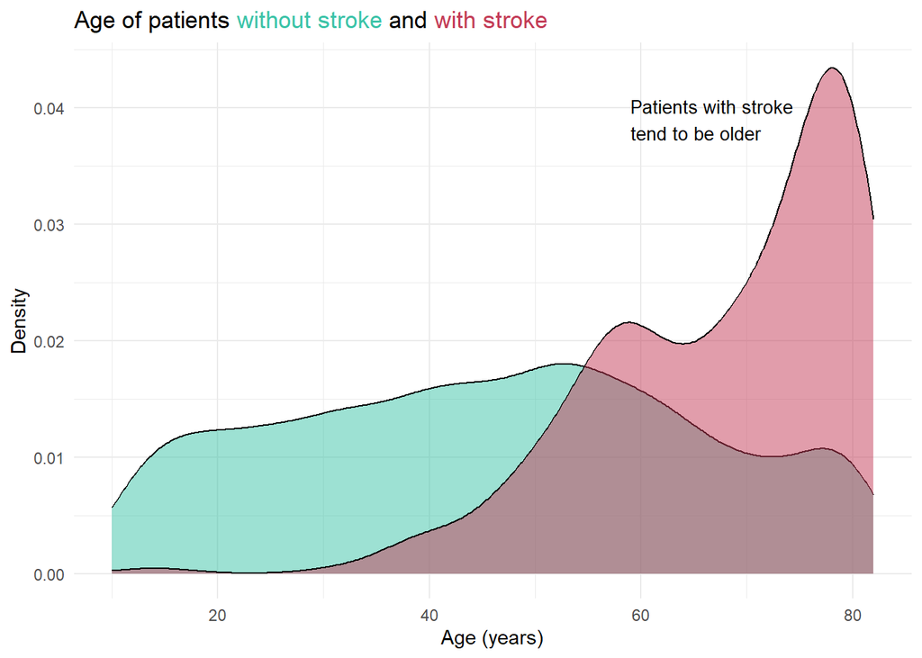

```r
library(ggtext)

ggplot(stroke_data2, aes(x=age, fill=stroke)) +
  geom_density(alpha=0.5) +
  theme_minimal() +
  scale_fill_manual(values = c("#3CC3A8", "#C33C57")) +
  labs(x = "Age (years)", y = "Density",
       title = "Age of patients <span style='color: #3CC3A8;'>without stroke</span> and <span style='color: #C33C57;'>with stroke</span>") +
  theme(plot.title = element_markdown(),
        legend.position = "none") +
  annotate("text", x=59, y=0.039, label="Patients with stroke\ntend to be older", hjust=0, size=3.5)
```

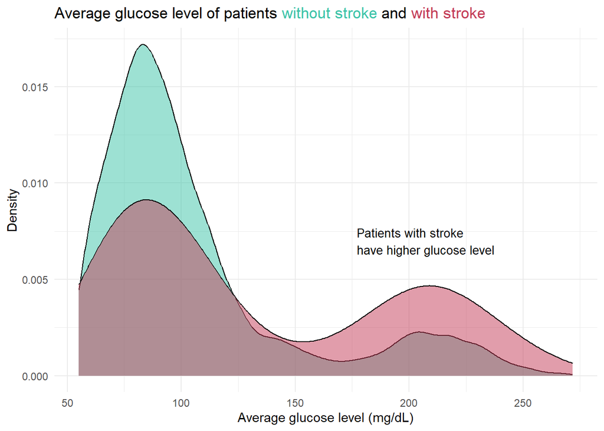

```r
ggplot(stroke_data2, aes(x=avg_glucose_level, fill=stroke)) +
  geom_density(alpha=0.5) +
  theme_minimal() +
  scale_fill_manual(values = c("#3CC3A8", "#C33C57")) +
  labs(x = "Average glucose level (mg/dL)", y = "Density",
       title = "Average glucose level of patients <span style='color: #3CC3A8;'>without stroke</span> and <span style='color: #C33C57;'>with stroke</span>") +
  theme(plot.title = element_markdown(),
        legend.position = "none") +
  annotate("text", x=177, y=0.007, label="Patients with stroke\nhave higher glucose level", hjust=0, size=3.5)
```

We can also add the scatterplot we made before to show the association between BMI and average glucose level.

[figure not shown]

```r
ggplot(arrange(stroke_data2, stroke),
       aes(x=bmi, y=avg_glucose_level, color=stroke)) +
  geom_point(alpha=0.5) +
  scale_fill_manual(values = c("#C33C57", "#3CC3A8")) +
  theme_minimal() +
  labs(x="BMI", y="Average glucose level (mg/dL)",
       title = "BMI vs average glucose level for patients <span style='color: #3CC3A8;'>without stroke</span> and <span style='color: #C33C57;'>with stroke</span>",
       subtitle = "Patients without stroke are more concentrated at the lower region") +
  theme(plot.title = element_markdown(),
        legend.position = "none")
```

If we still want to include BMI in our final analysis, we can still use the kernel density plot to show that the distribution between the two groups are similar.

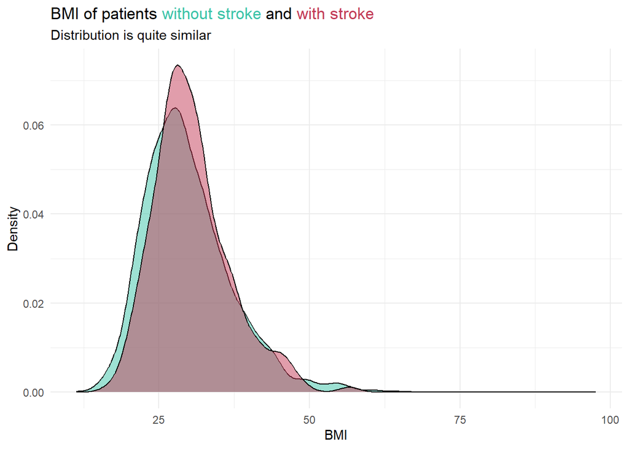

```r
ggplot(stroke_data2, aes(x=bmi, fill=stroke)) +
  geom_density(alpha=0.5) +
  theme_minimal() +
  scale_fill_manual(values = c("#3CC3A8", "#C33C57")) +
  labs(x = "BMI", y = "Density",
       title = "BMI of patients <span style='color: #3CC3A8;'>without stroke</span> and <span style='color: #C33C57;'>with stroke</span>",
       subtitle = "Distribution is quite similar") +
  theme(plot.title = element_markdown(),
        legend.position = "none")
```

For hypertension, heart disease, and smoke, we can maintain using the segmented bar chart. However, it may be better to use percentage for the label instead of count. Note in the code below, the `geom_col()`, `geom_text()`, `scale_fill_manual()`, and `scale_x_continous()` are put under the `patchwork` layout since the three plots share similar lines.

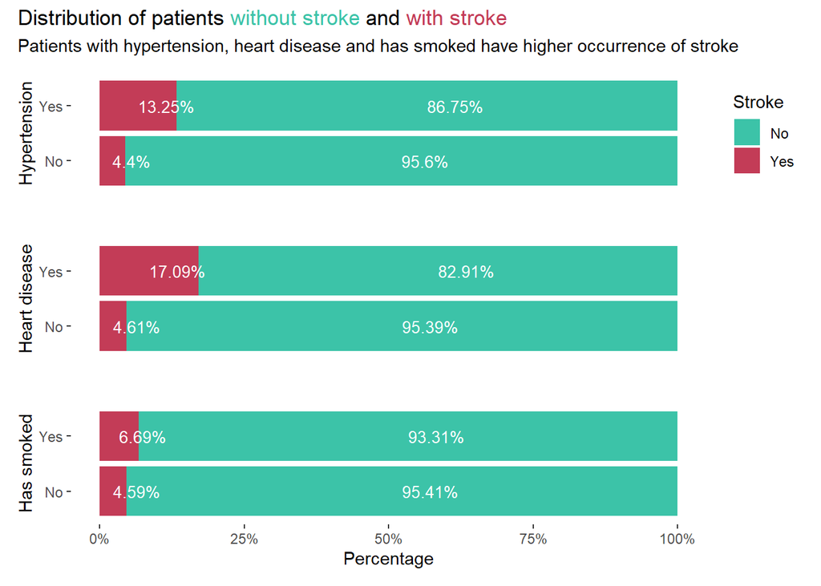

```r
library(patchwork)

df1 <- stroke_data2 %>% count(hypertension, stroke) %>% group_by(hypertension) %>%
  mutate(pct = paste0(round(prop.table(n)*100,2),"%"))
p1 <- ggplot(df1, aes(y=hypertension, x=n, fill=stroke, label=pct))+
  theme(axis.ticks.x = element_blank(),
        axis.text.x = element_blank()) +
  labs(x="", y="Hypertension", fill="Stroke")

df2 <- stroke_data2 %>% count(heart_disease, stroke) %>% group_by(heart_disease) %>%
  mutate(pct = paste0(round(prop.table(n)*100,2),"%"))
p2 <- ggplot(df2, aes(y=heart_disease, x=n, fill=stroke, label=pct))+
  theme(legend.position = "none",
        axis.ticks.x = element_blank(),
        axis.text.x = element_blank()) +
  labs(x="", y="Heart disease")

df3 <- stroke_data2 %>% count(smoke, stroke) %>% group_by(smoke) %>%
  mutate(pct = paste0(round(prop.table(n)*100,2),"%"))
p3 <- ggplot(df3, aes(y=smoke, x=n, fill=stroke, label=pct)) +
  theme(legend.position = "none") +
  labs(x="Percentage", y="Has smoked")

p1 / p2 / p3 &
  theme(panel.background = element_rect(fill="white")) &
  plot_annotation(title = "Distribution of patients <span style='color: #3CC3A8;'>without stroke</span> and <span style='color: #C33C57;'>with stroke</span>",
                  subtitle = "Patients with hypertension, heart disease and has smoked have higher occurrence of stroke",
                  theme = theme(plot.title = element_markdown())) &
  geom_col(position = "fill") &
  geom_text(position=position_fill(vjust=0.5),
             hjust=0, col="white", size=3.5, show.legend = FALSE) &
  scale_fill_manual(values = c("#3CC3A8", "#C33C57")) &
  scale_x_continuous(labels = scales::label_percent())
```

## Further Analysis

While visualization serves as a great tool for analysis, sometimes, we require something more concrete and objective. For this further analysis, we will be using logistic regression to identify the important factors. The logistic regression is a classification tool used to predict binary outcomes (yes/no, 0/1, etc.) using the explanatory variables.

The logistic regression uses the following model:

$$\text{Probability}(y=1)=\frac{\exp(\beta_0+\beta_1 x_1 + \cdots +
\beta_p x_p)}{1 + \exp(\beta_0+\beta_1 x_1 + \cdots + \beta_p x_p)}$$

where $\beta_0$ is the intercept parameter, and $\beta_1,...\beta_p$ are parameters associated with variables $x_1,x_2,...,x_p$. Positive parameter values indicate that the variable has a positive effect of making $y=1$.

In R, we can use logistic regression using the `glm()` function with the `family = binomial` argument.

```r
df <- mutate(stroke_data2, stroke = ifelse(stroke=="Yes",1,0))
log_model <- glm(stroke ~ . -id, data=df, family=binomial)
summary(log_model)
```

```
##
## Call:
## glm(formula = stroke ~ . - id, family = binomial, data = df)
##
## Coefficients:
##                          Estimate Std. Error z value Pr(>|z|)
## (Intercept)            -6.803e+00  1.050e+00  -6.479 9.21e-11 ***
## genderMale             -2.557e-02  1.542e-01  -0.166 0.868298
## genderOther            -1.154e+01  2.400e+03  -0.005 0.996163
## age                     7.203e-02  6.251e-03  11.522  < 2e-16 ***
## hypertensionYes         5.443e-01  1.741e-01   3.125 0.001777 **
## heart_diseaseYes        3.625e-01  2.068e-01   1.753 0.079679 .
## ever_marriedYes        -1.197e-01  2.471e-01  -0.484 0.628043
## work_typeGovt_job      -1.236e+00  1.094e+00  -1.130 0.258596
## work_typeNever_worked  -1.147e+01  5.098e+02  -0.022 0.982057
## work_typePrivate       -1.079e+00  1.080e+00  -0.999 0.317883
## work_typeSelf-employed -1.509e+00  1.098e+00  -1.374 0.169491
## Residence_typeUrban     8.554e-03  1.498e-01   0.057 0.954469
## avg_glucose_level       4.652e-03  1.294e-03   3.596 0.000324 ***
## bmi                     3.220e-03  1.186e-02   0.272 0.785912
## smokeYes                2.429e-01  1.524e-01   1.595 0.110802
## ---
## Signif. codes:  0 '***' 0.001 '**' 0.01 '*' 0.05 '.' 0.1 ' ' 1
##
## (Dispersion parameter for binomial family taken to be 1)
##
##     Null deviance: 1686.4  on 4449  degrees of freedom
## Residual deviance: 1364.4  on 4435  degrees of freedom
##   (188 observations deleted due to missingness)
## AIC: 1394.4
##
## Number of Fisher Scoring iterations: 15
```

The output shows the estimated parameters, standard error, z-value, and the *p*-value for each variable. Note that the *p*-value is for testing that the parameter is zero, or non-zero. A low *p*-value indicates that the data suggest that the parameter is non-zero, thus making the variable statistically significant.

Notice that only age, hypertension, heart disease, and average glucose level has *p*-value less than 0.1. These are the significant variables, according to the model. The parameter values are also positives, thus indicate that having higher age and average glucose level, or having hypertension or heart disease, lead to having higher probability of having stroke.

## Conclusion

This topic gives an example of analyzing data using visualization. When presented with a data, there are several steps required to perform a full analysis. First, construct the objectives of the analysis and investigation. Then, explore the data to have a clear understanding of it. Next, explore the data visually and identify key findings that worth mentioning and discussed. And then lastly, list down all the findings together with the supporting visuals. We hope that the example shown in this topic helps you with analyzing data using visualization.